# AS Project

Boshu Jiang

2024-03-12

## Question 1

Have a look at the data set, and make two different linear model to check whether the observation for Palm Beach county impacts the results from the linear regression models.

```r
# Explore the data
elections <- read.table("BushGore.dat", header = TRUE)
head(elections)
```

```
##     County Perot Buchanan
## 1  Alachua  8072      262
## 2    Baker   667       73
## 3      Bay  5922      248
## 4 Bradford   819       65
## 5  Brevard 25249      570
## 6  Broward 38964      789
```

```r
summary(elections)
```

```
##     County              Perot          Buchanan
##  Length:67          Min.   :  316   Min.   :   9.0
##  Class :character   1st Qu.: 1072   1st Qu.:  46.5
##  Mode  :character   Median : 3739   Median : 120.0
##                     Mean   : 7221   Mean   : 259.1
##                     3rd Qu.: 8700   3rd Qu.: 285.5
##                     Max.   :38964   Max.   :3407.0
```

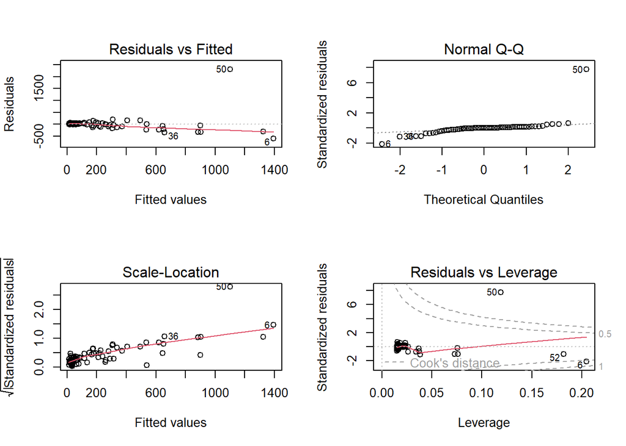

```r
# Perform Linear Regression using Perot's votes in 1996 to predict Buchanan's votes in 2000
par(mfrow=c(2,2))
model <- lm(Buchanan ~ Perot, data=elections)

# Analyze Palm Beach County
plot(model)  # This will give you several diagnostic plots
```

```r
# Evaluate the Model
summary(model)
```

```
##
## Call:
## lm(formula = Buchanan ~ Perot, data = elections)
##
## Residuals:
##     Min      1Q  Median      3Q     Max
## -604.44  -66.82    2.53   33.45 2307.47
##
## Coefficients:
##              Estimate Std. Error t value Pr(>|t|)
## (Intercept)  1.081433  49.899462   0.022    0.983
## Perot        0.035735   0.004352   8.211 1.23e-11 ***
## ---
## Signif. codes:  0 '***' 0.001 '**' 0.01 '*' 0.05 '.' 0.1 ' ' 1
##
## Residual standard error: 317.3 on 65 degrees of freedom
## Multiple R-squared:  0.5091, Adjusted R-squared:  0.5016
## F-statistic: 67.41 on 1 and 65 DF,  p-value: 1.234e-11
```

```r
# Create a model without Palm Beach County
elections_without_palm <- subset(elections, County != "PalmBeach")
model_without_palm <- lm(Buchanan ~ Perot, data=elections_without_palm)
summary(model_without_palm)
```

```
##
## Call:
## lm(formula = Buchanan ~ Perot, data = elections_without_palm)
##
## Residuals:
##     Min      1Q  Median      3Q     Max
## -197.38  -45.49  -18.64   22.84  272.08
##
## Coefficients:
##              Estimate Std. Error t value Pr(>|t|)
## (Intercept) 45.689948  13.981299   3.268  0.00174 **
## Perot        0.024143   0.001281  18.847  < 2e-16 ***
## ---
## Signif. codes:  0 '***' 0.001 '**' 0.01 '*' 0.05 '.' 0.1 ' ' 1
##
## Residual standard error: 88.31 on 64 degrees of freedom
## Multiple R-squared:  0.8473, Adjusted R-squared:  0.8449
## F-statistic: 355.2 on 1 and 64 DF,  p-value: < 2.2e-16
```

The observation for Palm Beach County significantly impacts the results of the linear regression model. The exclusion of Palm Beach County results in a much lower residual standard error and a higher $R^2$ value, which means that the model without Palm Beach County provides a much better fit to the data. The change in the coefficient for Perot’s votes also indicates that the Palm Beach observation was influencing the slope and the interception of the regression line. Additionally, the extremely high residual in the first model points to Palm Beach County being an outlier with a substantial effect on the model’s predictions. Such outliers can have a large leverage effect, meaning they can significantly affect the slope and intercept of the regression line.

In conclusion, the Palm Beach County observation is likely an outlier or a point with high leverage and greatly impacts the linear regression model. In practical terms, this means that including this observation may not give an accurate picture of the overall relationship between Perot’s and Buchanan’s votes across Florida counties. This may indicate that the voting in Palm Beach County were incorrect, so that it has a great impact to the linear model.

## (a)

```r
# Original model
model1 <- lm(gamble ~ sex + status + income + verbal, data=teengamb)

# Model with square root transformation
model2 <- lm(sqrt(gamble) ~ sex + status + income + verbal, data=teengamb)

# Summary of both models
summary(model1)
```

```
##
## Call:
## lm(formula = gamble ~ sex + status + income + verbal, data = teengamb)
##
## Residuals:
##     Min      1Q  Median      3Q     Max
## -51.082 -11.320  -1.451   9.452  94.252
##
## Coefficients:
##              Estimate Std. Error t value Pr(>|t|)
## (Intercept)  22.55565   17.19680   1.312   0.1968
## sex         -22.11833    8.21111  -2.694   0.0101 *
## status        0.05223    0.28111   0.186   0.8535
## income        4.96198    1.02539   4.839 1.79e-05 ***
## verbal       -2.95949    2.17215  -1.362   0.1803
## ---
## Signif. codes:  0 '***' 0.001 '**' 0.01 '*' 0.05 '.' 0.1 ' ' 1
##
## Residual standard error: 22.69 on 42 degrees of freedom
## Multiple R-squared:  0.5267, Adjusted R-squared:  0.4816
## F-statistic: 11.69 on 4 and 42 DF,  p-value: 1.815e-06
```

```r
summary(model2)
```

```
##
## Call:
## lm(formula = sqrt(gamble) ~ sex + status + income + verbal, data = teengamb)
##
## Residuals:
##     Min      1Q  Median      3Q     Max
## -4.6606 -1.0961 -0.2564  0.9786  5.4178
##
## Coefficients:
##             Estimate Std. Error t value Pr(>|t|)
## (Intercept)  2.97707    1.57947   1.885  0.06638 .
## sex         -2.04450    0.75416  -2.711  0.00968 **
## status       0.03688    0.02582   1.428  0.16057
## income       0.47938    0.09418   5.090 7.94e-06 ***
## verbal      -0.42360    0.19950  -2.123  0.03967 *
## ---
## Signif. codes:  0 '***' 0.001 '**' 0.01 '*' 0.05 '.' 0.1 ' ' 1
##
## Residual standard error: 2.084 on 42 degrees of freedom
## Multiple R-squared:  0.5646, Adjusted R-squared:  0.5231
## F-statistic: 13.61 on 4 and 42 DF,  p-value: 3.362e-07
```

The second model is much better than the first one because the second model had lower residual standard error and higher $R^2$ value, which means that it better fit our data. From the p-value of each predictors, we can also find that the second model has lower p-value, which makes it more accurate.

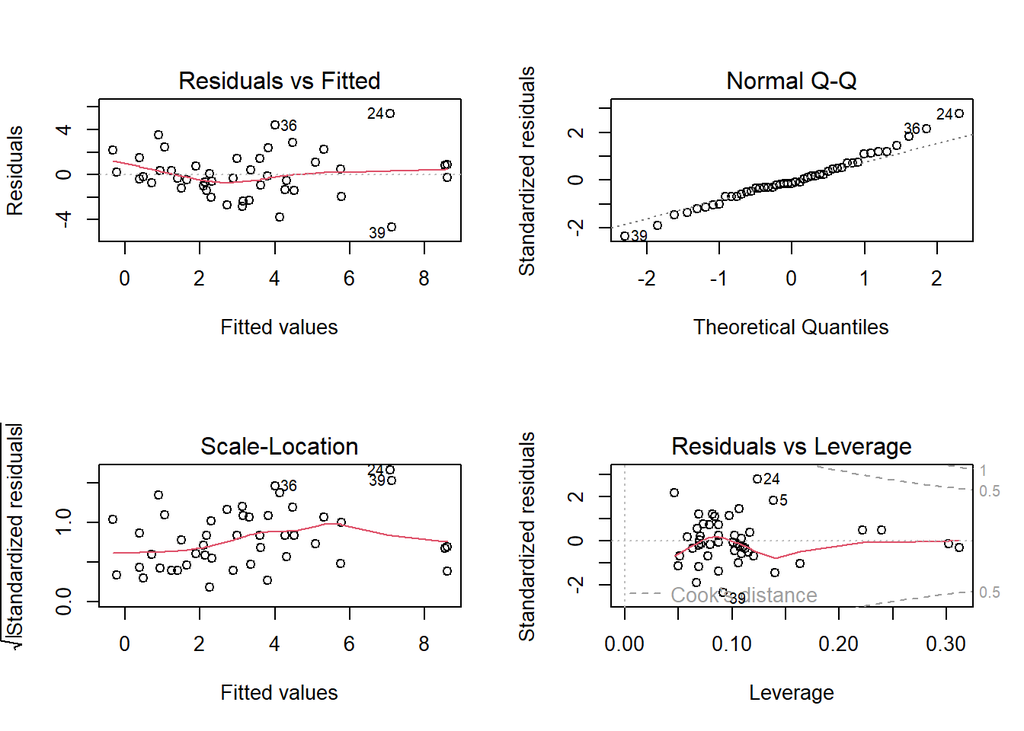

```r
par(mfrow=c(2,2))
plot(model2)
```

From first and third plots, we find that the data may not have a constant variance, which violates the assumption of homoscedasticity. If the assumption of homoscedasticity is perfectly satisfied, the residual point in plot 1 should be randomly scattered and the red line in plot 3 should be flat. From the second plot, we find that the residuals might not be perfectly normal, particularly at the tails.

## (b)

```r
# Coefficient for sex variable representing the difference between male and female
sex_coe<-summary(model2)$coefficients["sex",]
# Extract the estimated difference
estimated_difference <- sex_coe["Estimate"]

# Calculate 95% confidence interval for the difference
confidence_interval <- confint(model2, "sex", level=0.95)

# Output the estimated difference and confidence interval
estimated_difference
```

```
##  Estimate
## -2.044502
```

```r
confidence_interval
```

```
##         2.5 %     97.5 %
## sex -3.566467 -0.5225375
```

The point estimate of the difference in the square root of gambling expenditure between males and females is $-2.044502$ and a 95% condidence level for this is $[-3.566467, -0.5225375]$.

## (c)

```r
# Find the maximum values for socioeconomic status, income, and verbal score
max_status <- max(teengamb$status, na.rm = TRUE)
max_income <- max(teengamb$income, na.rm = TRUE)
max_verbal <- max(teengamb$verbal, na.rm = TRUE)

newdata <- data.frame(
  sex=0,
  status=max_status,
  income=max_income,
  verbal=max_verbal
)
# Predict the amount with a 95% prediction interval on the square root scale
prediction_sqrt_scale <- predict(model2, newdata, interval="prediction")
prediction <- prediction_sqrt_scale^2
prediction
```

```
##        fit      lwr      upr
## 1 75.65038 13.80692 187.1336
```

The estimation is $75.65038$ with a 95% prediction interval $[13.80692, 187.1336]$

## (d)

```r
# Model without the income variable
model3 <- lm(sqrt(gamble) ~ income, data=teengamb)

# Use anova to compare the two models
anova(model3, model2)
```

```
## Analysis of Variance Table
##
## Model 1: sqrt(gamble) ~ income
## Model 2: sqrt(gamble) ~ sex + status + income + verbal
##   Res.Df    RSS Df Sum of Sq      F    Pr(>F)
## 1     45 272.76
## 2     42 182.41  3    90.346 6.9339 0.0006774 ***
## ---
## Signif. codes:  0 '***' 0.001 '**' 0.01 '*' 0.05 '.' 0.1 ' ' 1
```

By comparing the RSS for two models and checking the p-value, we find that the additional predictors (sex, status, and verbal) contribute significantly to the model and that the full model with these predictors provides a statistically significantly better fit to the data than the reduced model with income alone. Therefore, these variables do have a significant effect on the square root of the gambling expenditure when controlling for income.

## (e)

```r
# model selection starting from the full model
step_model <- step(model2, direction="both")
```

```
## Start:  AIC=73.74
## sqrt(gamble) ~ sex + status + income + verbal
##
##          Df Sum of Sq    RSS    AIC
## <none>                182.41 73.738
## - status  1     8.862 191.28 73.968
## - verbal  1    19.580 202.00 76.530
## - sex     1    31.919 214.33 79.317
## - income  1   112.528 294.94 94.322
```

```r
summary(step_model)
```

```
##
## Call:
## lm(formula = sqrt(gamble) ~ sex + status + income + verbal, data = teengamb)
##
## Residuals:
##     Min      1Q  Median      3Q     Max
## -4.6606 -1.0961 -0.2564  0.9786  5.4178
##
## Coefficients:
##             Estimate Std. Error t value Pr(>|t|)
## (Intercept)  2.97707    1.57947   1.885  0.06638 .
## sex         -2.04450    0.75416  -2.711  0.00968 **
## status       0.03688    0.02582   1.428  0.16057
## income       0.47938    0.09418   5.090 7.94e-06 ***
## verbal      -0.42360    0.19950  -2.123  0.03967 *
## ---
## Signif. codes:  0 '***' 0.001 '**' 0.01 '*' 0.05 '.' 0.1 ' ' 1
##
## Residual standard error: 2.084 on 42 degrees of freedom
## Multiple R-squared:  0.5646, Adjusted R-squared:  0.5231
## F-statistic: 13.61 on 4 and 42 DF,  p-value: 3.362e-07
```

By using the step function, we iteratively remove the least significant variables based on AIC from a model predicting the square root of gambling expenditure. Notice that when dropping sex variable, it increases AIC more significant than dropping status and verbal, suggesting that variable sex is a much more important and stable predictor than status and verbal. The p-value of our final selected model suggests our conclusion, since the p-value of sex predictor is 0.00968. It is statistically significant at the 1% level (using the common alpha level of 0.05). This suggests that sex has a significant effect on the square root of the gambling expenditure in the final model.